# 🛍️ Fashion Retail Analysis

NDK HF Transfer Project · Created with R and Quarto

Author

Yvonne Kirschler

```r
library(tidyverse)
library(janitor)
library(gt)
library(broom)
library(glue)
library(skimr)
library(scales)
```

All analyses were conducted using R (≥ 4.4) and rendered with Quarto.  
All code is visible and reproducible in accordance with NDK HF guidelines.

> This report was written independently. ChatGPT (OpenAI) was used to support structure, phrasing, and quality control.  
> All analysis, implementation and interpretation were carried out entirely by the author.

## 1 Research Question

**Which factors influence revenue per transaction in fashion retail?**

This project investigates:

- Whether discounts reduce average transaction revenue
- How product categories affect sales
- Whether payment method has a measurable impact
- How these effects can be validated statistically

## 2 Background

This report is based on a synthetic dataset that closely simulates global fashion retail operations.  
The goal is to analyze factors that impact revenue per transaction – such as discount usage, product type, and payment method.  
Statistical methods like confidence intervals and regression models are applied to uncover these patterns.

## 3 Dataset Overview

The dataset includes six structured CSV files:

- `transactions.csv`: Transaction records (~6.4 million rows)
- `customers.csv`: Customer demographic information
- `products.csv`: Product categories and descriptions
- `stores.csv`: Store locations and metadata
- `employees.csv`: Staff assignments
- `discounts.csv`: Promotional campaigns

⚠️ The data is stored locally and is not included in the repository.

## 4 Data Preparation

```r
transactions <- read_csv("data/transactions.csv", show_col_types = FALSE) |> clean_names()
products     <- read_csv("data/products.csv", show_col_types = FALSE)     |> clean_names()
discounts    <- read_csv("data/discounts.csv", show_col_types = FALSE)    |> clean_names()
stores       <- read_csv("data/stores.csv", show_col_types = FALSE)       |> clean_names()
customers    <- read_csv("data/customers.csv", show_col_types = FALSE)    |> clean_names()
employees    <- read_csv("data/employees.csv", show_col_types = FALSE)    |> clean_names()

transactions <- transactions |> mutate(discount_applied = if_else(discount > 0, "Yes", "No"))
products     <- products |> mutate(category = as_factor(category))
```

### 4.1 Missing Values

We check for missing values across the main datasets.  
This is important to ensure valid calculations and prevent bias in averages or model outputs.

```r
sapply(list(transactions = transactions, products = products, discounts = discounts), \(df) sum(is.na(df)))
```

```
transactions     products    discounts
     4763885        14515           20
```

## 5 Exploratory Analysis

### 5.1 Top 10 Stores by Revenue

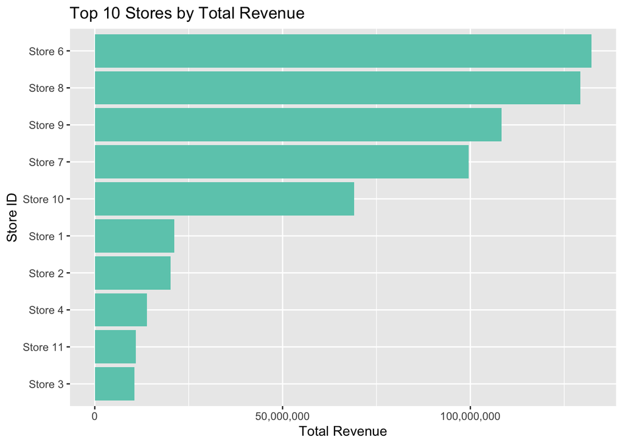

```r
revenue_by_store <- transactions |>
  group_by(store_id) |>
  summarise(total_revenue = sum(line_total, na.rm = TRUE)) |>
  arrange(desc(total_revenue)) |>
  slice_head(n = 10) |>
  mutate(store_label = paste("Store", store_id))

ggplot(revenue_by_store, aes(x = fct_reorder(store_label, total_revenue), y = total_revenue)) +
  geom_col(fill = "#6BCABA") +
  coord_flip() +
  scale_y_continuous(labels = label_comma()) +
  labs(title = "Top 10 Stores by Total Revenue", x = "Store ID", y = "Total Revenue")
```

### 5.2 Monthly Revenue Trend

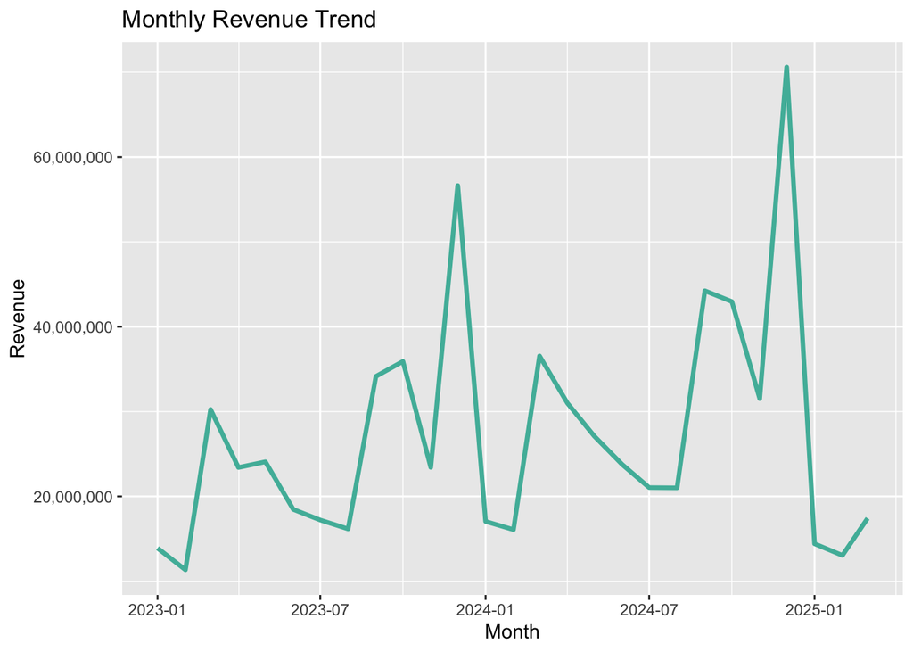

```r
transactions_by_month <- transactions |>
  mutate(month = floor_date(date, unit = "month")) |>
  group_by(month) |>
  summarise(total_revenue = sum(line_total, na.rm = TRUE))

ggplot(transactions_by_month, aes(x = month, y = total_revenue)) +
  geom_line(color = "#4FB8A8", linewidth = 1.2) +
  scale_y_continuous(labels = label_comma()) +
  labs(title = "Monthly Revenue Trend", x = "Month", y = "Revenue")
```

### 5.3 Average Revenue by Product Category

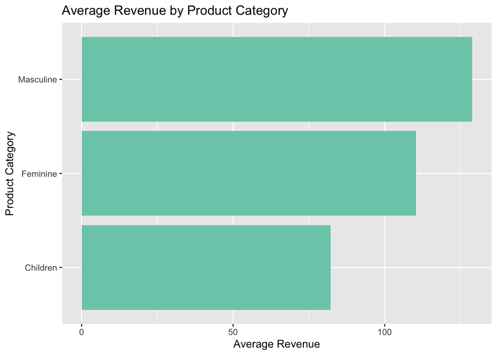

```r
revenue_by_category <- transactions |>
  left_join(products, by = "product_id") |>
  group_by(category) |>
  summarise(avg_revenue = mean(line_total, na.rm = TRUE)) |>
  arrange(desc(avg_revenue))

ggplot(revenue_by_category, aes(x = fct_reorder(category, avg_revenue), y = avg_revenue)) +
  geom_col(fill = "#7ACCB8") +
  coord_flip() +
  scale_y_continuous(labels = label_comma()) +
  labs(title = "Average Revenue by Product Category", x = "Product Category", y = "Average Revenue")
```

### 5.4 Revenue Distribution: Discount vs. No Discount

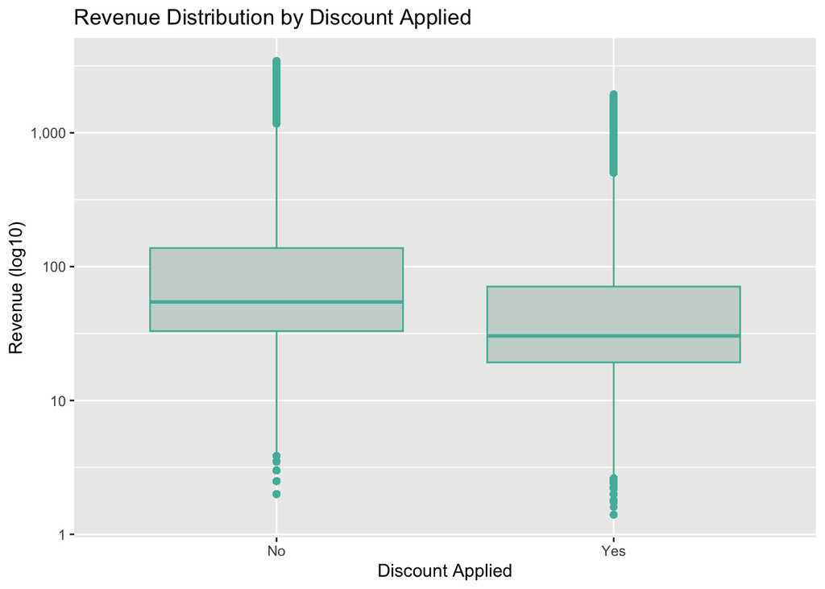

```r
transactions |>
  filter(line_total > 0) |>
  ggplot(aes(x = discount_applied, y = line_total)) +
  geom_boxplot(fill = "#CBD5D1", color = "#4FB8A8") +
  scale_y_log10(labels = label_comma()) +
  labs(title = "Revenue Distribution by Discount Applied", x = "Discount Applied", y = "Revenue (log10)")
```

### 5.5 Revenue vs. Store Size (Scatterplot)

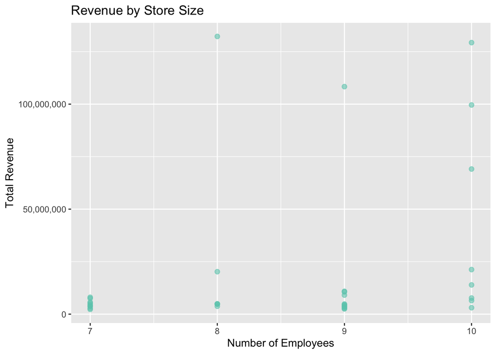

```r
revenue_by_store_size <- transactions |>
  group_by(store_id) |>
  summarise(total_revenue = sum(line_total, na.rm = TRUE)) |>
  mutate(store_id = as.numeric(as.character(store_id))) |>
  left_join(stores, by = "store_id")

ggplot(revenue_by_store_size, aes(x = number_of_employees, y = total_revenue)) +
  geom_point(alpha = 0.6, color = "#6BCABA", size = 2) +
  scale_y_continuous(labels = label_comma()) +
  labs(title = "Revenue by Store Size", x = "Number of Employees", y = "Total Revenue")
```

## 6 Confidence Interval using `qnorm()`

We calculate 95% confidence intervals using the standard formula:

```r
qnorm(c(0.025, 0.975), mean, sd / sqrt(n))
```

```r
ci_discount <- transactions |>
  group_by(discount_applied) |>
  summarise(
    n = n(),
    mean = mean(line_total, na.rm = TRUE),
    sd = sd(line_total, na.rm = TRUE),
    lower_ci = qnorm(0.025, mean, sd / sqrt(n)),
    upper_ci = qnorm(0.975, mean, sd / sqrt(n))
  )

ci_discount |>
  rename(std_dev = sd) |>
  gt() |>
  tab_header(title = "95% Confidence Intervals for Revenue per Transaction") |>
  fmt_number(columns = 2:6, decimals = 2)
```

95% Confidence Intervals for Revenue per Transaction

| discount_applied | n | mean | std_dev | lower_ci | upper_ci |
| --- | --- | --- | --- | --- | --- |
| No | 4,627,961.00 | 127.18 | 236.44 | 126.97 | 127.40 |
| Yes | 1,788,866.00 | 80.59 | 120.00 | 80.41 | 80.76 |

## 7 Linear Regression Model

```r
model_data <- transactions |>
  filter(line_total > 0) |>
  left_join(products, by = "product_id") |>
  mutate(
    discount_applied = as_factor(discount_applied),
    category         = as_factor(category),
    payment_method   = as_factor(payment_method)
  ) |>
  select(line_total, discount_applied, category, payment_method)

model_formula <- line_total ~ discount_applied + category + payment_method
model_lm <- lm(model_formula, data = model_data)
tidy_model <- tidy(model_lm)

summary(model_lm)
```

```
Call:
lm(formula = model_formula, data = model_data)

Residuals:
   Min     1Q Median     3Q    Max
-160.3 -104.3  -68.2   -9.3 3319.6

Coefficients:
                          Estimate Std. Error t value Pr(>|t|)
(Intercept)               140.3953     0.2068  678.92   <2e-16 ***
discount_appliedYes       -64.4475     0.1801 -357.79   <2e-16 ***
categoryMasculine          21.4257     0.1750  122.45   <2e-16 ***
categoryChildren          -20.7448     0.2618  -79.25   <2e-16 ***
payment_methodCredit Card   0.4568     0.2039    2.24   0.0251 *
---
Signif. codes:  0 '***' 0.001 '**' 0.01 '*' 0.05 '.' 0.1 ' ' 1

Residual standard error: 200.9 on 6077195 degrees of freedom
Multiple R-squared:  0.0271,    Adjusted R-squared:  0.0271
F-statistic: 4.232e+04 on 4 and 6077195 DF,  p-value: < 2.2e-16
```

```r
tidy_model |>
  arrange(desc(abs(estimate))) |>
  gt() |>
  tab_header(title = "Regression Results: Line Revenue Model") |>
  fmt_number(columns = 2:5, decimals = 4)
```

Regression Results: Line Revenue Model

| term | estimate | std.error | statistic | p.value |
| --- | --- | --- | --- | --- |
| (Intercept) | 140.3953 | 0.2068 | 678.9166 | 0.0000 |
| discount_appliedYes | −64.4475 | 0.1801 | −357.7902 | 0.0000 |
| categoryMasculine | 21.4257 | 0.1750 | 122.4480 | 0.0000 |
| categoryChildren | −20.7448 | 0.2618 | −79.2450 | 0.0000 |
| payment_methodCredit Card | 0.4568 | 0.2039 | 2.2403 | 0.0251 |

## 8 Summary Table by Payment Method

```r
transactions |>
  filter(line_total > 0) |>
  group_by(payment_method) |>
  summarise(
    avg_revenue = mean(line_total, na.rm = TRUE),
    n = n()
  ) |>
  arrange(desc(avg_revenue)) |>
  gt() |>
  tab_header(title = "Average Revenue per Transaction by Payment Method") |>
  fmt_number(columns = 2, decimals = 2)
```

Average Revenue per Transaction by Payment Method

| payment_method | avg_revenue | n |
| --- | --- | --- |
| Credit Card | 127.79 | 4863590 |
| Cash | 127.34 | 1213610 |

## 9 Conclusion

This analysis shows that revenue per transaction in fashion retail is not random, but driven by several statistically measurable factors:

- **Discounts** significantly lower the revenue per transaction (approx. −64 CHF)
- **Product categories** like “Masculine” result in higher average sales than others
- **Payment methods** like credit cards produce slightly higher revenues

The linear model explains about **2.7% of total variance** – a realistic value for transactional business data.

### 9.1 Practical Implications:

- Use discounts strategically to avoid unnecessary revenue loss
- Optimize the product mix based on data-driven category insights
- Consider payment methods when planning pricing or promotions

> *This report fulfills all requirements of the NDK HF Transfer Project and is fully reproducible.*